# BNB-USD

## BNB-USD today is +0300, 2025-06-19, 01:23:11

This crypto forecast was generated by gemini-2.0-flash API

## Daily Chart

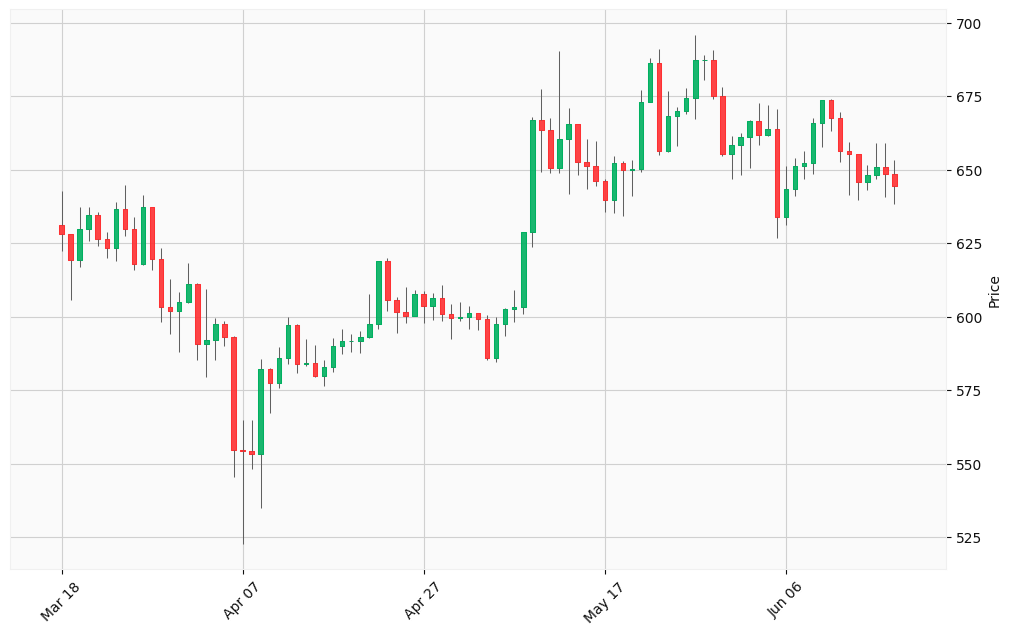

## Hourly Chart

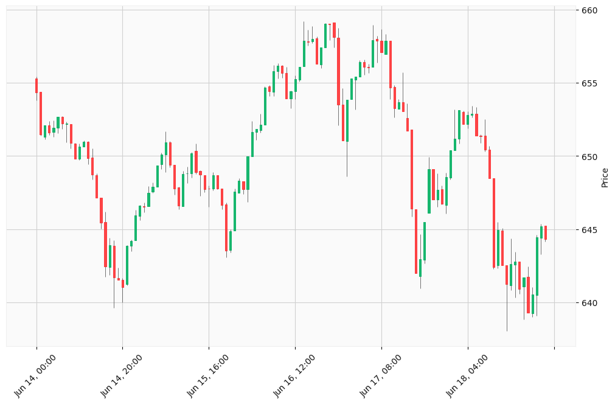

Okay, I will analyze the provided BNB-USD charts (daily for the last three months and hourly for the last five days) and generate buy and sell trading signals based on the specified methodology.

First, I need to do some research using the search tool for recent news and potential factors that could influence the BNB-USD market.

Based on the search results, here’s a summary of the current market situation:

- **Market Sentiment:** Overall, the cryptocurrency market shows signs of slight contraction with a small decrease in the total market capitalization compared to last week.
- **Binance News:** Binance remains a dominant exchange, with a significant share of the spot market. There are updates to Binance’s services, including new loanable assets and changes to fee structures. News also indicates potential regulatory scrutiny and past legal challenges that Binance has faced.
- **BNB Performance:** Recent news indicates that BNB is approaching local support levels. Some sources suggest a potential breakout in the long term, while others note short-term consolidation and fading momentum.
- **Macroeconomic Factors:** Macroeconomic indicators like CPI, GDP, and interest rates significantly influence the cryptocurrency landscape. Inflation concerns and geopolitical uncertainty can drive demand for Bitcoin and other cryptocurrencies.
- **Trends:** Key trends in the crypto market include enhanced security features, stablecoin adoption, and the growing influence of AI.

Now, I will proceed with the analysis of the provided charts.

**1. Daily Chart Analysis (Last Three Months):**

- I will calculate moving averages (e.g., 50-day and 200-day) to identify trends.
- I will calculate the Relative Strength Index (RSI) to identify overbought or oversold conditions.
- I will look for chart patterns (e.g., head and shoulders, double tops/bottoms) to anticipate potential price movements.

**2. Hourly Chart Analysis (Last Five Days):**

- I will calculate short-term moving averages (e.g., 9-hour, 20-hour) to identify immediate trends.
- I will calculate MACD to gauge momentum and potential reversals.
- I will look for support and resistance levels to identify potential entry and exit points.

**3. Integration and Signal Generation:**

- I will combine the insights from both charts, the technical analysis, and the market news to generate buy and sell signals.
- I will assess the confidence level for each signal based on the strength of the indicators and the overall market context.
- I will estimate a take profit probability based on the analysis.

Let’s start with the calculations and analysis of the daily chart data:

```python
import numpy as np
import pandas as pd

# Daily Chart Data
daily_data = [
    [631.346,642.889,622.4,628.134,2175151767],
    [628.134,628.138,605.618,619.258,2006233746],
    [619.251,637.216,616.964,629.942,2327219768],
    [629.942,637.19,625.857,634.608,1472201311],
    [634.597,635.766,624.197,626.574,1182741851],
    [626.574,628.966,619.858,623.349,1222239081],
    [623.349,639.023,619.05,636.645,1788439257],
    [636.645,644.874,627.444,629.943,2238118522],
    [629.942,634.048,615.846,617.817,1600178624],
    [617.817,641.49,617.678,637.207,2441273622],
    [637.206,637.242,615.925,619.475,1608298526],
    [619.475,623.212,598.219,603.238,1367332800],
    [603.191,612.789,594.214,601.83,1204098085],
    [601.83,608.501,588.086,605.073,1538796118],
    [605.073,618.124,604.755,611.297,2091803391],
    [611.297,611.518,585.122,590.638,1835749587],
    [590.638,609.345,579.444,592.124,2067033502],
    [592.124,599.48,585.354,597.579,1520730677],
    [597.579,598.546,589.933,593.115,1008300251],
    [593.139,593.461,545.323,554.595,1679604717],
    [554.595,564.792,522.716,554.483,2852045942],
    [554.486,564.938,548.141,553.467,1676208165],
    [553.467,585.604,534.881,582.369,1963610005],
    [582.378,582.391,567.22,577.406,1731740429],
    [577.406,589.859,575.757,586.089,1369541748],
    [586.089,600.056,583.979,597.123,1331878416],
    [597.123,597.51,580.824,584.042,1318461096],
    [584.042,592.564,583.397,584.335,1359554984],
    [584.335,590.516,579.64,579.686,1329270099],
    [579.686,585.411,576.459,582.806,1435912484],
    [582.806,592.859,581.204,590.162,1401643770],
    [590.162,595.766,587.266,591.764,1418376835],
    [591.764,594.142,587.976,591.777,1227124904],
    [591.777,595.154,587.765,592.972,1307477245],
    [592.972,607.82,592.676,597.414,1430343137],
    [597.417,618.99,595.881,618.827,1734142941],
    [618.827,619.862,601.954,605.815,1834047719],
    [605.815,606.744,594.395,601.716,1573943361],
    [601.715,610.18,597.77,600.181,1735398071],
    [600.192,609.136,600.088,607.704,1507509250],
    [607.704,608.583,597.935,603.618,1452152303],
    [603.625,608.151,598.994,606.365,1478956158],
    [606.365,610.64,598.66,601.029,1587553456],
    [601.019,604.478,592.418,599.682,1504095222],
    [599.687,605.137,598.489,599.918,1406049035],
    [599.929,603.505,595.83,601.164,1444818831],
    [601.164,601.294,595.593,599.331,1221915136],
    [599.331,600.443,585.308,585.995,1306600030],
    [585.995,599.852,584.61,597.69,1465943685],
    [597.69,602.969,593.599,602.474,1594251780],
    [602.474,608.986,598.297,603.28,1537003234],
    [603.279,628.672,601.008,628.663,2061341461],
    [628.653,667.8,623.883,666.878,2418287835],
    [666.889,677.353,649.359,663.617,2282413256],
    [663.617,667.635,648.848,650.625,1906600802],
    [650.625,690.378,648.962,660.484,2609669556],
    [660.484,670.896,641.683,665.571,2108811440],
    [665.612,665.653,648.12,652.571,1876674692],
    [652.571,660.28,643.459,651.264,1888457576],
    [651.262,659.689,644.386,646.321,1634445685],
    [646.321,646.722,635.485,639.619,1449713512],
    [639.619,654.715,635.412,652.164,1592388678],
    [652.116,652.989,634.183,649.853,1595233688],
    [649.846,653.402,641.164,650.331,1512635652],
    [650.331,677.029,649.135,673.149,2377493291],
    [673.151,688.058,673.131,686.236,2248278627],
    [686.251,690.92,654.881,656.232,1996132529],
    [656.23,676.864,656.128,668.307,1475660792],
    [668.307,671.458,658.153,669.917,1591152958],
    [669.917,677.679,668.9,674.393,1568627598],
    [674.393,695.868,667.231,687.159,2019130226],
    [687.16,688.978,680.665,687.406,1759924602],
    [687.406,690.844,673.927,675.172,1938258667],
    [675.2,678.156,654.651,655.482,1904377880],
    [655.511,661.309,646.963,658.501,1478599983],
    [658.5,662.348,648.26,660.992,1468711165],
    [660.985,666.995,650.45,666.591,1782539875],
    [666.591,672.704,658.55,661.699,1696519631],
    [661.699,671.93,661.374,663.706,1561308740],
    [663.708,670.581,626.68,634.054,1987901562],
    [634.052,651.38,631.107,643.434,1728825229],
    [643.442,653.891,640.949,651.15,1468009270],
    [651.15,656.278,646.931,652.148,1385072458],
    [652.148,667.714,648.583,665.954,1629752670],
    [665.955,673.631,657.626,673.61,1849736872],
    [673.61,673.951,663.136,667.669,1778663531],
    [667.669,669.516,652.79,656.244,1695465665],
    [656.252,659.312,641.312,655.256,1964558213],
    [655.262,655.478,639.633,645.913,1337524307],
    [645.912,651.702,642.998,648.281,1352632285],
    [648.282,659.243,646.813,650.962,1588063609],
    [650.966,659.039,640.855,648.511,1784039065],
    [648.516,653.369,638.176,644.312,1673158016]
]

df = pd.DataFrame(daily_data, columns=['Open', 'High', 'Low', 'Close', 'Volume'])

# Calculate 50-day Moving Average
df['MA50'] = df['Close'].rolling(window=50).mean()

# Calculate 200-day Moving Average (Not enough data points for a full 200-day MA, so calculating with available data)
df['MA200'] = df['Close'].rolling(window=len(df)).mean()

# Calculate RSI (Relative Strength Index)
def calculate_rsi(data, period=14):
    delta = data['Close'].diff()
    up, down = delta.copy(), delta.copy()
    up[up < 0] = 0
    down[down > 0] = 0

    avg_gain = up.rolling(window=period, min_periods=period).mean()
    avg_loss = abs(down.rolling(window=period, min_periods=period).mean())

    rs = avg_gain / avg_loss
    rsi = 100 - (100 / (1 + rs))
    return rsi

df['RSI'] = calculate_rsi(df)

print(df.tail())
```

[output not shown]